# Klasyfikacja

Krzysztof Słomczyński

26 maja 2017

# Czym jest klasyfikacja?

Klasyfikacja polega na przewidywaniu **dyskretnej** zmiennej objaśnianej.

Przykładowe problemy klasyfikacji:

- Czy wiadomość email jest spamem, czy nie?
- Czy transakcja jest oszustwem, czy nie?
- Czy nowotwór jest złośliwy, czy nie?

Najprostszą wersją tego zagadnienia jest klasyfikacja binarna, gdzie zmienna objaśniana Y z założenia może przyjąć tylko jedną z dwóch wartości – Fałsz (0) lub Prawdę (1).

# Regresja liniowa w problemie klasyfikacji

```r
library(ggplot2)
```

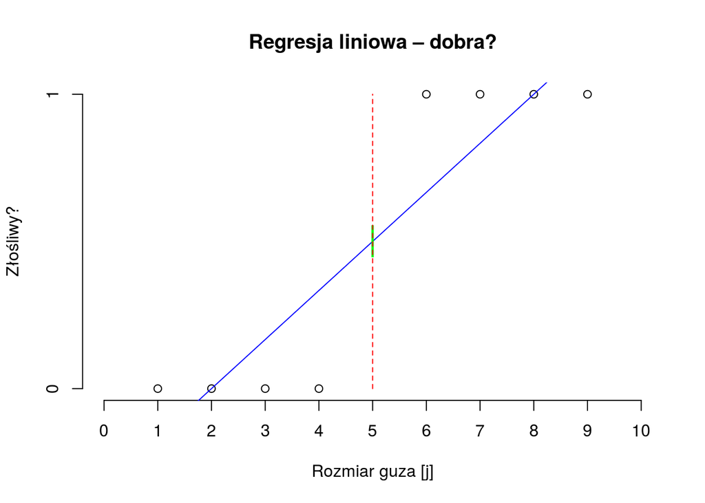

```r
tumor <- data.frame(x = c(1:4, 6:9), y = c(rep(c(0, 1), each = 4)))
lm_model <- lm(formula = y ~ x, data = tumor)

plot(x = tumor$x,
     y = tumor$y,
     main = "Regresja liniowa – dobra?",
     xlab = "Rozmiar guza [j]",
     ylab = "Złośliwy?",
     xlim = c(0, 10),
     axes = FALSE)
axis(1, at = 0:10)
axis(2, at = c(0, 1))
curve(predict(object = lm_model, data.frame(x = x), type = "resp"),
      col = "blue", add = TRUE)
points(5, 0.5, cex = 2, col = "green", pch = "|")
lines(x = c(5, 5), y = c(0, 1), col = "red", lty = 2)
```

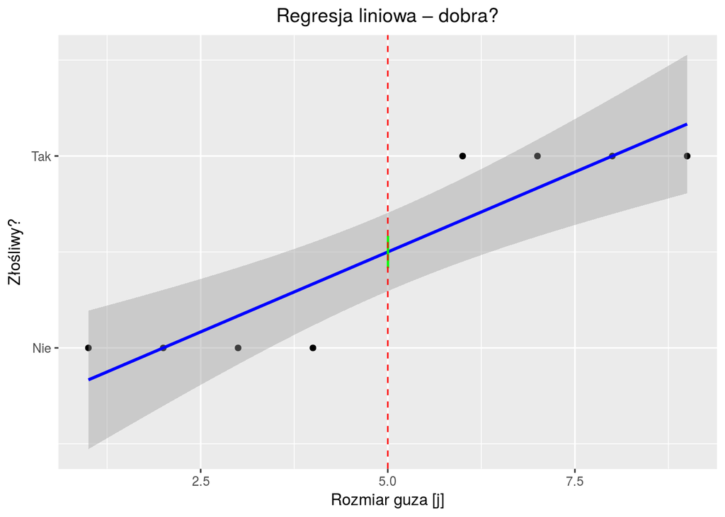

```r
ggplot(data = tumor, mapping = aes(x = x, y = y)) +
  geom_point() +
  stat_smooth(method = "lm", col = "blue") +
  geom_point(mapping = aes(x = x, y = y),
             data = data.frame(x = 5, y = 0.5),
             cex = 8, col = "green", pch = "|") +
  geom_vline(xintercept = 5, col = "red", lty = 2) +
  scale_y_continuous(breaks = c(0, 1), labels = c("Nie", "Tak")) +
  labs(x = "Rozmiar guza [j]", y = "Złośliwy?") +
  ggtitle("Regresja liniowa – dobra?") +
  theme(plot.title = element_text(hjust = 0.5))
```

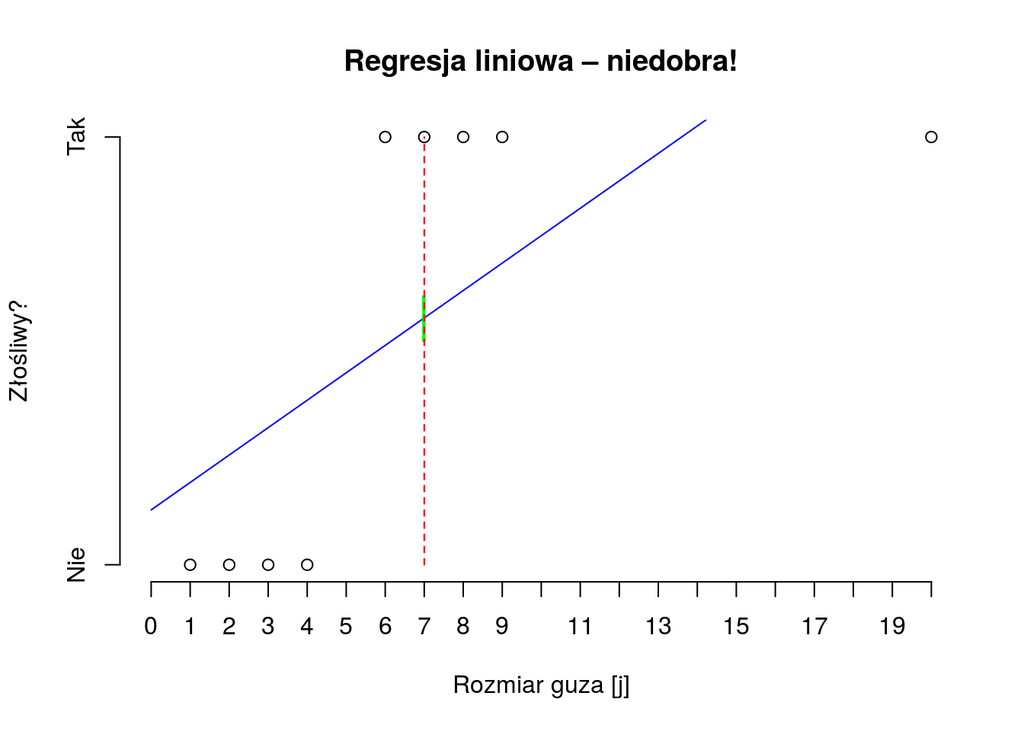

```r
tumor[9, ] <- c(20, 1)
lm_model <- lm(formula = y ~ x, data = tumor)

plot(x = tumor$x,
     y = tumor$y,
     main = "Regresja liniowa – niedobra!",
     xlab = "Rozmiar guza [j]",
     ylab = "Złośliwy?",
     xlim = c(0, 20),
     axes = FALSE)
axis(1, at = 0:20)
axis(2, at = c(0, 1), labels = c("Nie", "Tak"))
curve(predict(object = lm_model, data.frame(x = x), type = "resp"),
      col = "blue", add = TRUE)
points(7, 0.575, cex = 2, col = "green", pch = "|")
lines(x = c(7, 7), y = c(0, 1), col = "red", lty = 2)
```

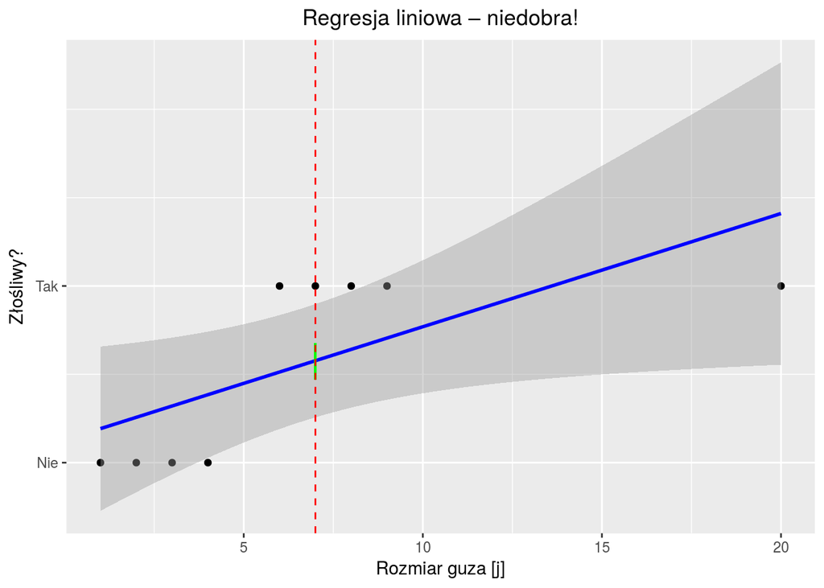

```r
ggplot(data = tumor, mapping = aes(x = x, y = y)) +
  geom_point() +
  stat_smooth(method = "lm", col = "blue") +
  geom_point(mapping = aes(x = x, y = y),
             data = data.frame(x = 7, y = 0.575),
             cex = 8, col = "green", pch = "|") +
  geom_vline(xintercept = 7, col = "red", lty = 2) +
  scale_y_continuous(breaks = c(0, 1), labels = c("Nie", "Tak")) +
  labs(x = "Rozmiar guza [j]", y = "Złośliwy?") +
  ggtitle("Regresja liniowa – niedobra!") +
  theme(plot.title = element_text(hjust = 0.5))
```

Dziwnym byłoby przewidywanie wartości Y wykraczającej poza przedział [0, 1], (poza “Nie” i “Tak”).

# Regresja logistyczna

Najpopularniejszym algorytmem służącym do rozwiązywania problemów klasyfikacji jest **regresja logistyczna**. Wykorzystuje ona funkcję sigmoidalną zadaną wzorem $g(z) = \frac{1}{1 + e^{-x}}$.

```r
glm_model <- glm(formula = y ~ x, family = binomial, data = tumor)
```

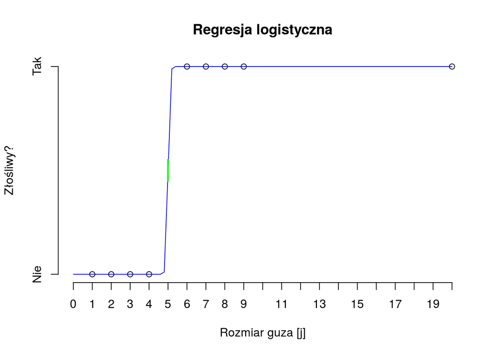

```r
plot(x = tumor$x,
     y = tumor$y,
     main = "Regresja logistyczna",
     xlab = "Rozmiar guza [j]",
     ylab = "Złośliwy?",
     xlim = c(0, 20),
     axes = FALSE)
axis(1, at = 0:20)
axis(2, at = c(0, 1), labels = c("Nie", "Tak"))
curve(predict(object = glm_model, data.frame(x = x), type = "resp"),
      col = "blue", add = TRUE)
points(5, 0.5, cex = 2, col = "green", pch = "|")
```

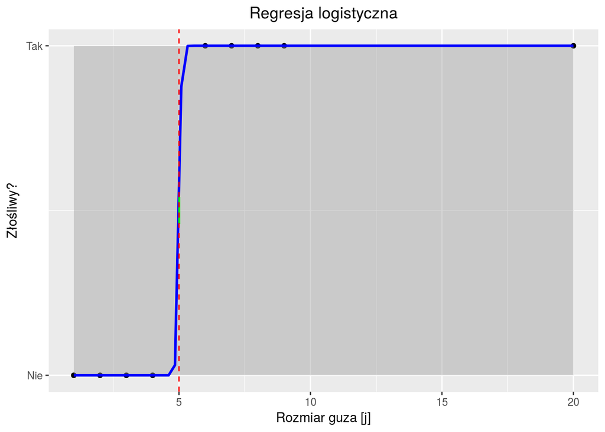

```r
ggplot(data = tumor, mapping = aes(x = x, y = y)) +
  geom_point() +
  stat_smooth(method = "glm", method.args = list(family = "binomial"),
              col = "blue") +
  geom_point(mapping = aes(x = x, y = y),
             data = data.frame(x = 5, y = 0.5),
             cex = 8, col = "green", pch = "|") +
  geom_vline(xintercept = 5, col = "red", lty = 2) +
  scale_y_continuous(breaks = c(0, 1), labels = c("Nie", "Tak")) +
  labs(x = "Rozmiar guza [j]", y = "Złośliwy?") +
  ggtitle("Regresja logistyczna") +
  theme(plot.title = element_text(hjust = 0.5))
```

## Operacje na danych biologicznych.

`broom` – pakiet ułatwiający korzystanie z modeli otrzymanych za pomocą podstawowego pakietu `stats`.

`caret` – pakiet ujednolicający niezwykle bogate środowisko pracy (bazujące na wielu innych pakietach) w uczeniu statystycznym.

`corrplot` – pakiet służący do wizualizacji macierzy korelacji

Nie będziemy zagłębiać się w pakiet `caret`. Posłużymy się nim tylko do preprocessingu.

```r
library(broom)
library(caret)
```

```r
library(corrplot)
```

## Podział danych na dwa zestawy – treningowy i testowy.

```r
data_set <- read.csv("../data/bio_data.csv")

# Pozbycie się niepełnych obserwacji i identyfikatora
data_set <- data_set[complete.cases(data_set),
                     colnames(data_set) != "bcr_patient_barcode"]

# Sprawdzenie, czy któreś ze zmiennych objaśniajacych nie posiadają wariancji bliskiej zeru
near_zero_var <- nearZeroVar(x = data_set, saveMetrics = TRUE)
near_zero_var
```

```
##               freqRatio percentUnique zeroVar   nzv
## times          2.666667    68.6530612   FALSE FALSE
## cancer         2.873606     0.2448980   FALSE FALSE
## status         4.751174     0.1632653   FALSE FALSE
## drug_therapy   3.342960     0.4897959   FALSE FALSE
## TP53           1.902844     0.1632653   FALSE FALSE
## TTN            4.724299     0.1632653   FALSE FALSE
## PIK3CA         3.785156     0.1632653   FALSE FALSE
## ADCY5          7.000000    99.5102041   FALSE FALSE
## ADCY6          1.000000   100.0000000   FALSE FALSE
## ADCY7          1.000000   100.0000000   FALSE FALSE
## ADCY8        316.500000    47.9183673   FALSE FALSE
## ADCY9          1.000000   100.0000000   FALSE FALSE
## ADCYAP1R1    109.000000    81.5510204   FALSE FALSE
```

```r
# Sprawdzenie, czy niektóre zmienne nie są ze sobą silnie skorelowane
matrix_set <- data.matrix(data_set)
correlation <- cor(matrix_set)
summary(correlation[upper.tri(correlation)])
```

```
##      Min.   1st Qu.    Median      Mean   3rd Qu.      Max.
## -0.526381 -0.087047 -0.005283  0.005619  0.105256  0.539189
```

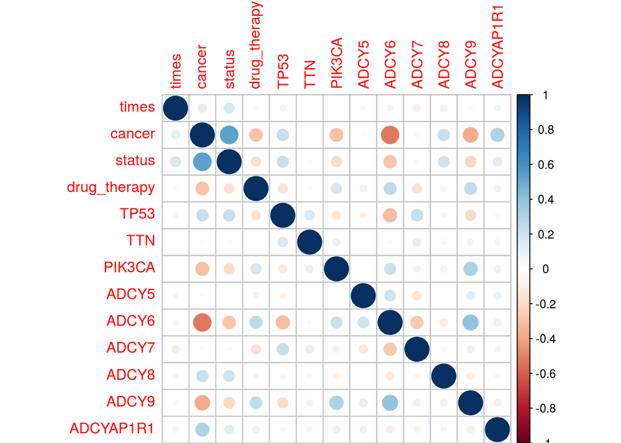

```r
corrplot(correlation)
```

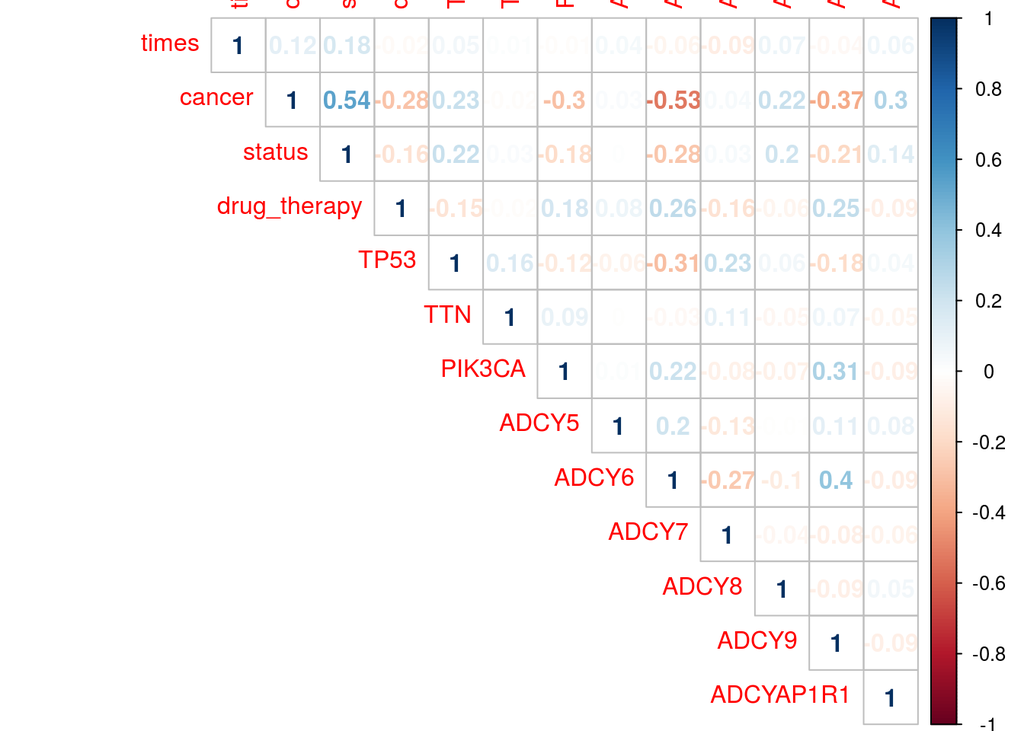

```r
corrplot(correlation, method = "number", type = "upper")
```

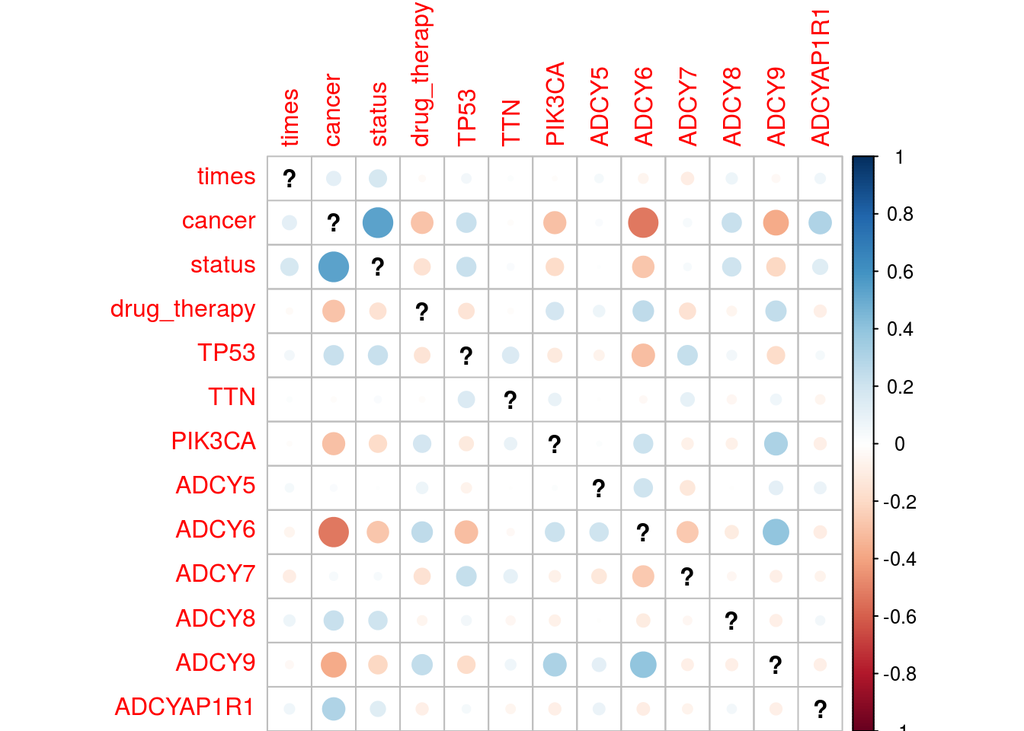

```r
diag(correlation) <- NA
corrplot(correlation)
```

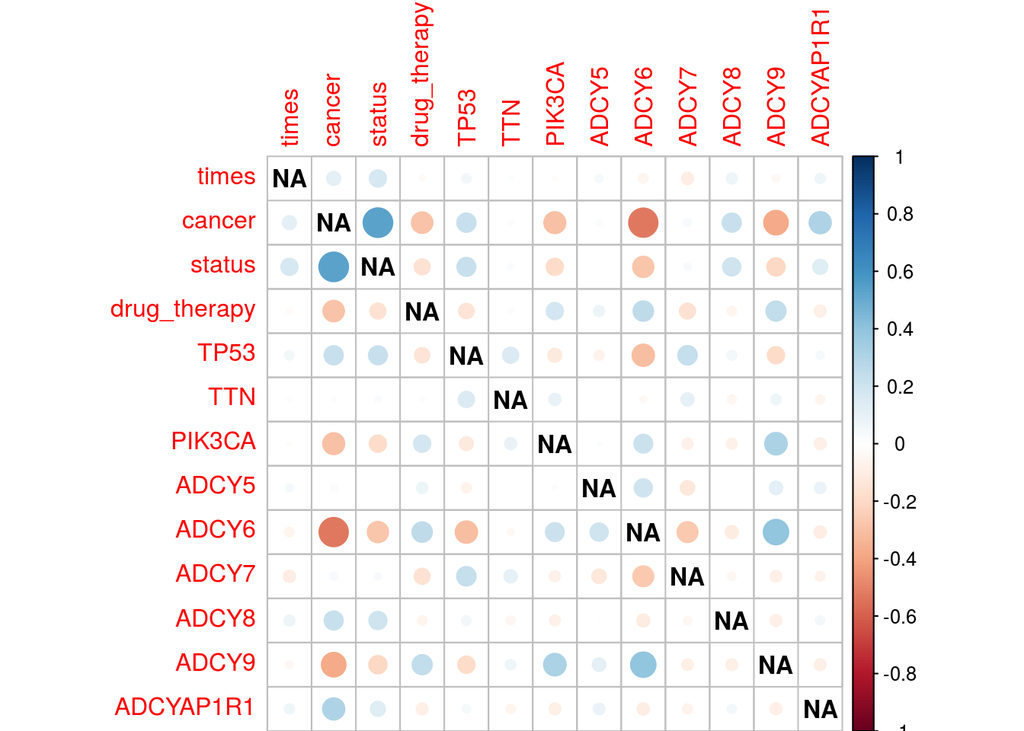

```r
corrplot(correlation, na.label = "NA")
```

```r
find_correlation <- findCorrelation(correlation, cutoff = .5,
                                    verbose = TRUE, names = TRUE)
```

```
## Compare row 2  and column  9 with corr  0.526
##   Means:  0.248 vs 0.126 so flagging column 2
## All correlations <= 0.5
```

```r
find_correlation
```

```
## [1] "cancer"
```

```r
# Sprawdzenie liniowych zależności
comboInfo <- findLinearCombos(matrix_set)
comboInfo
```

```
## $linearCombos
## list()
##
## $remove
## NULL
```

```r
set.seed(42)
train_rows <- createDataPartition(y = data_set$status, p = 0.8, list = FALSE)
train <- data_set[train_rows, ]
test <- data_set[-train_rows, ]
```

## Szkolenie modelu

Kropka w formule oznacza, że chcemy stworzyć model od wszystkich dostępnych zmiennych objaśniających.

```r
glm_model <- glm(formula = status ~ ., data = train)
```

Przyjrzyjmy się wyszkolonemu modelowi

```r
glm_model
```

```
##
## Call:  glm(formula = status ~ ., data = train)
##
## Coefficients:
##                            (Intercept)
##                             -1.035e-01
##                                  times
##                              5.897e-05
##                             cancerHNSC
##                              1.795e-01
##                               cancerOV
##                              4.978e-01
##               drug_therapychemotherapy
##                              2.003e-02
##            drug_therapyhormone therapy
##                              2.842e-02
##              drug_therapyimmunotherapy
##                             -7.751e-02
##             drug_therapyother, specify
##                              2.905e-01
## drug_therapytargeted molecular therapy
##                             -1.855e-01
##                               TP53TRUE
##                              7.625e-02
##                                TTNTRUE
##                              3.531e-02
##                             PIK3CATRUE
##                             -2.109e-02
##                                  ADCY5
##                             -2.219e-05
##                                  ADCY6
##                              2.081e-05
##                                  ADCY7
##                              2.290e-05
##                                  ADCY8
##                              8.165e-05
##                                  ADCY9
##                              3.678e-06
##                              ADCYAP1R1
##                             -7.724e-05
##
## Degrees of Freedom: 979 Total (i.e. Null);  962 Residual
## Null Deviance:       142.5
## Residual Deviance: 93.87     AIC: 520.3
```

Informacje nie są zbyt czytelne. W celu ujednolicenia informacji o modelu posłużymy się funkcjami z pakietu `broom`.

```r
glm_tidy <- tidy(glm_model)
glm_tidy
```

```
##                                      term      estimate    std.error
## 1                             (Intercept) -1.034908e-01 1.837302e-01
## 2                                   times  5.897368e-05 1.312393e-05
## 3                              cancerHNSC  1.795404e-01 3.553188e-02
## 4                                cancerOV  4.977840e-01 3.301125e-02
## 5                drug_therapychemotherapy  2.003271e-02 1.816369e-01
## 6             drug_therapyhormone therapy  2.841635e-02 1.823315e-01
## 7               drug_therapyimmunotherapy -7.751104e-02 2.295873e-01
## 8              drug_therapyother, specify  2.904740e-01 2.558201e-01
## 9  drug_therapytargeted molecular therapy -1.854947e-01 2.399044e-01
## 10                               TP53TRUE  7.624600e-02 2.351045e-02
## 11                                TTNTRUE  3.530784e-02 2.714586e-02
## 12                             PIK3CATRUE -2.108787e-02 2.690075e-02
## 13                                  ADCY5 -2.218794e-05 3.372329e-05
## 14                                  ADCY6  2.080575e-05 1.423274e-05
```

[output cut: 23 more lines]

```r
glm_glance <- glance(glm_model)
glm_glance
```

```
##   null.deviance df.null   logLik      AIC      BIC deviance df.residual
## 1      142.4602     979 -241.172 520.3439 613.2074 93.86553         962
```

Możemy zauważyć, że ciągła zmienna objaśniająca `times` występuje tylko raz, natomiast każda dyskretna zmienna objaśniająca (np. `cancer`) została zastąpiona o jedną mniej zmienną niż posiadała pierwotnie (w tym wypadku dwoma). Każda z tych nowych zmiennych (tzw. dummy variables) przybierają wartości 0 i 1 (dla danej obserwacji wystąpił dany typ raka, albo nie wystąpił). Wariantowi z trzecią – brakującą zmienną – odpowiada sytuacja, w której wszystkie nowopowstałe zmienne (od danej zmiennej) przyjmują wartość 0.

Przyjrzyjmy się istotności poszczególnych cech.

```r
summary(glm_model)
```

```
##
## Call:
## glm(formula = status ~ ., data = train)
##
## Deviance Residuals:
##      Min        1Q    Median        3Q       Max
## -0.72930  -0.13127  -0.03264   0.03121   1.02089
##
## Coefficients:
##                                          Estimate Std. Error t value
## (Intercept)                            -1.035e-01  1.837e-01  -0.563
## times                                   5.897e-05  1.312e-05   4.494
## cancerHNSC                              1.795e-01  3.553e-02   5.053
## cancerOV                                4.978e-01  3.301e-02  15.079
## drug_therapychemotherapy                2.003e-02  1.816e-01   0.110
## drug_therapyhormone therapy             2.842e-02  1.823e-01   0.156
## drug_therapyimmunotherapy              -7.751e-02  2.296e-01  -0.338
## drug_therapyother, specify              2.905e-01  2.558e-01   1.135
## drug_therapytargeted molecular therapy -1.855e-01  2.399e-01  -0.773
## TP53TRUE                                7.625e-02  2.351e-02   3.243
## TTNTRUE                                 3.531e-02  2.715e-02   1.301
## PIK3CATRUE                             -2.109e-02  2.690e-02  -0.784
## ADCY5                                  -2.219e-05  3.372e-05  -0.658
## ADCY6                                   2.081e-05  1.423e-05   1.462
## ADCY7                                   2.290e-05  2.302e-05   0.995
## ADCY8                                   8.165e-05  3.098e-05   2.635
## ADCY9                                   3.678e-06  1.858e-05   0.198
## ADCYAP1R1                              -7.724e-05  1.043e-04  -0.740
##                                        Pr(>|t|)
## (Intercept)                             0.57338
## times                                  7.85e-06 ***
## cancerHNSC                             5.21e-07 ***
## cancerOV                                < 2e-16 ***
## drug_therapychemotherapy                0.91220
## drug_therapyhormone therapy             0.87618
## drug_therapyimmunotherapy               0.73573
## drug_therapyother, specify              0.25646
## drug_therapytargeted molecular therapy  0.43959
## TP53TRUE                                0.00122 **
## TTNTRUE                                 0.19368
## PIK3CATRUE                              0.43328
## ADCY5                                   0.51073
## ADCY6                                   0.14412
## ADCY7                                   0.32003
## ADCY8                                   0.00854 **
## ADCY9                                   0.84311
## ADCYAP1R1                               0.45932
## ---
## Signif. codes:  0 '***' 0.001 '**' 0.01 '*' 0.05 '.' 0.1 ' ' 1
##
## (Dispersion parameter for gaussian family taken to be 0.09757331)
##
##     Null deviance: 142.460  on 979  degrees of freedom
## Residual deviance:  93.866  on 962  degrees of freedom
## AIC: 520.34
##
## Number of Fisher Scoring iterations: 2
```

Możemy zauważyć, że istotnych jest 5 zmiennych objaśniających (przy czym trzy wywodzą się z dwóch kategorycznych). Zapiszmy sobie ich nazwy na przyszłość. Nie zapomnijmy przy tym, o zmiennej objaśnianej.

```r
significant_attributes <- c("status", "times", "cancer", "TP53", "ADCY8")
```

## Predykcja

```r
prediction <- predict(object = glm_model, newdata = test, type = "response")
prediction <- round(x = prediction, digits = 0)
prediction_frame <- data.frame(actual = test$status, predicted = prediction,
                               row.names = 1:length(test$status))
prediction_frame <- sapply(X = prediction_frame, FUN = plyr::mapvalues,
                           from = c(0, 1), to = c("Survived", "Passed"))
prediction_frame <- as.data.frame(prediction_frame)
confusion_matrix <- table(prediction_frame$predicted, prediction_frame$actual,
                          dnn = c("predicted", "actual"))
confusion_matrix <- confusionMatrix(confusion_matrix, positive = "Passed")
confusion_matrix
```

```
## Confusion Matrix and Statistics
##
##           actual
## predicted  Passed Survived
##   Passed       21       18
##   Survived     19      187
##
##                Accuracy : 0.849
##                  95% CI : (0.7979, 0.8914)
##     No Information Rate : 0.8367
##     P-Value [Acc > NIR] : 0.3387
##
##                   Kappa : 0.4416
##  Mcnemar's Test P-Value : 1.0000
##
##             Sensitivity : 0.52500
##             Specificity : 0.91220
##          Pos Pred Value : 0.53846
##          Neg Pred Value : 0.90777
##              Prevalence : 0.16327
##          Detection Rate : 0.08571
##    Detection Prevalence : 0.15918
##       Balanced Accuracy : 0.71860
##
##        'Positive' Class : Passed
##
```

```r
glm_score <- confusion_matrix$byClass["Sensitivity"] +
  confusion_matrix$byClass["Specificity"]
glm_score <- unname(glm_score)
glm_score
```

```
## [1] 1.437195
```

```r
unname(glm_score/2 == confusion_matrix$byClass["Balanced Accuracy"])
```

```
## [1] TRUE
```

Wizualizacja macierzy pomyłek.

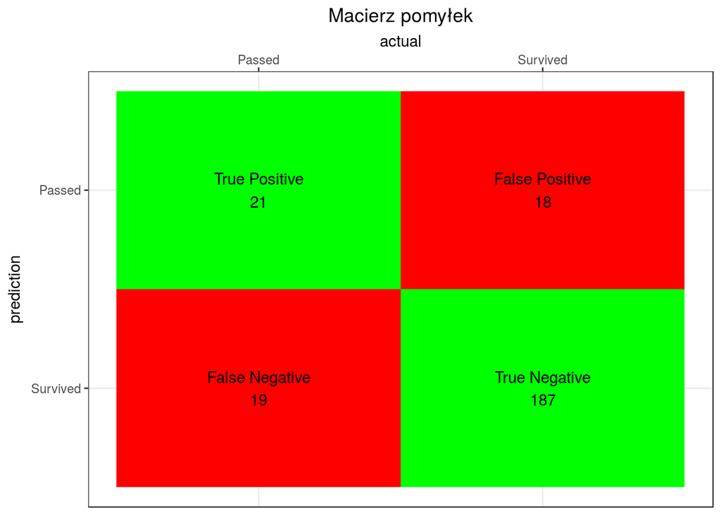

```r
actual_class <- rep(dimnames(confusion_matrix$table)$actual,
                    each = 2)
prediction_class <- rep(dimnames(confusion_matrix$table)$predicted,
                        times = 2)
label <- paste(c("True Positive", "False Negative",
                 "False Positive", "True Negative"),
               as.vector(confusion_matrix$table),
               sep = "\n")
fill <- c("green", "red", "red", "green")
confusion_frame <- data.frame(actual = actual_class,
                              prediction = prediction_class,
                              label = label,
                              fill = fill)

glm_confusion_matrix <- ggplot(data =  confusion_frame,
                               mapping = aes(x = actual, y = prediction,
                                             fill = fill, label = label)) +
  geom_tile() +
  geom_text() +
  scale_fill_identity() +
  scale_x_discrete(position = "top") +
  scale_y_discrete(limits = rev(levels(confusion_frame$prediction))) +
  ggtitle("Macierz pomyłek") +
  theme_bw() +
  theme(plot.title = element_text(hjust = 0.5))
glm_confusion_matrix
```

Parametrów wynikających z macierzy pomyłek jest znacznie więcej. Skupimy się na dwóch poniższych. Za ich pomocą będziemy oceniać skuteczność naszego modelu.

- True Positive Rate – TPR, Sensitivity

  $True Positive Rate = \frac{True Positive}{True Positive + False Negative}$
- True Negative Rate – TNR, Specificity

  $True Negative Rate = \frac{True Negative}{True Negative + False Positive}$

Oba te parametry uwzględniają liczebność swoich klas, co jest **bardzo** istotne w ocenie modelu. W naszym przypadku klasy różnią się od siebie liczebnością w znaczącym stopniu (zmarło 40 pacjentów, przeżyło 205). Zauważmy, że naiwnie zakładając przeżycie każdego pacjenta otrzymujemy aż 205 trafnych predykcji z 245 uzyskując tylko pozornie lepszy model. Dlatego tak **bardzo** ważne jest uwzględnienie liczebności klas.

```r
205/245
```

```
## [1] 0.8367347
```

```r
glm_score/2
```

```
## [1] 0.7185976
```

```r
205/245 > glm_score/2
```

```
## [1] TRUE
```

Receiver operating characteristic

```r
library(ROCR)
```

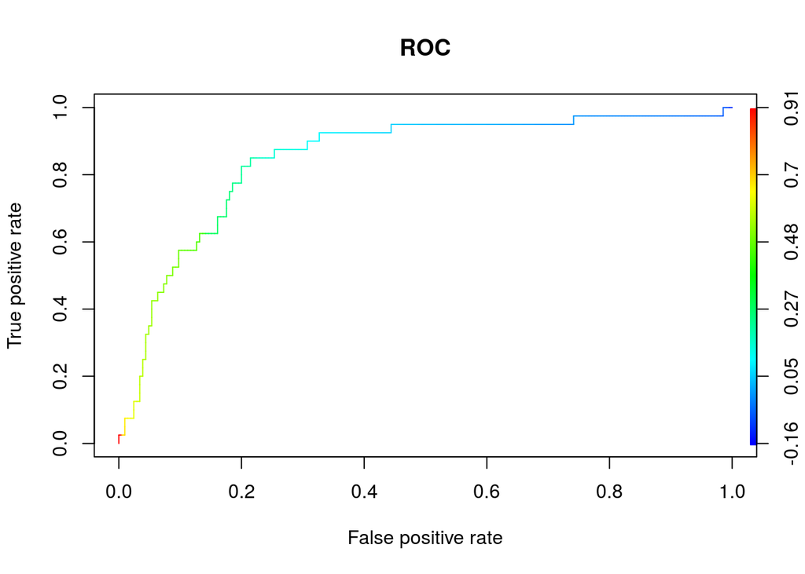

```r
scores <- predict(object = glm_model, newdata = test, type = "response")
labels <- test$status
pred <- prediction(predictions = scores, labels = labels)
perf <- performance(prediction.obj = pred, measure = "tpr", x.measure = "fpr")
plot(perf, colorize = TRUE, main = "ROC")
```

## Selekcja zmiennych – uproszczenie modelu

Dobór zmiennych ma na celu sprawienie, że model będzie bardziej zrozumiały dla człowieka. Łatwiej jest wyjaśnić pewne prawa i zachowania bazując na mniejszej ilości predyktorów. Zbudujmy więc tym razem model tylko na tych zmiennych, które okazały się istotne przy budowaniu wcześniejszego modelu.

```r
# Wybór zmiennych w zbiorze treningowym i testowym
train_lite <- train[, significant_attributes]
test_lite <- test[, significant_attributes]

# Szkolenie i podsumowanie modelu
glm_model_lite <- glm(formula = status ~ ., data = train_lite)
summary(glm_model_lite)
```

```
##
## Call:
## glm(formula = status ~ ., data = train_lite)
##
## Deviance Residuals:
##      Min        1Q    Median        3Q       Max
## -0.72614  -0.14325  -0.03016   0.02312   1.01910
##
## Coefficients:
##               Estimate Std. Error t value Pr(>|t|)
## (Intercept) -2.817e-02  1.687e-02  -1.670 0.095202 .
## times        5.745e-05  1.305e-05   4.403 1.18e-05 ***
## cancerHNSC   1.683e-01  2.878e-02   5.848 6.80e-09 ***
## cancerOV     4.650e-01  2.645e-02  17.579  < 2e-16 ***
## TP53TRUE     8.017e-02  2.154e-02   3.722 0.000209 ***
## ADCY8        8.003e-05  3.090e-05   2.590 0.009750 **
## ---
## Signif. codes:  0 '***' 0.001 '**' 0.01 '*' 0.05 '.' 0.1 ' ' 1
##
## (Dispersion parameter for gaussian family taken to be 0.09745174)
##
##     Null deviance: 142.460  on 979  degrees of freedom
## Residual deviance:  94.918  on 974  degrees of freedom
## AIC: 507.27
##
## Number of Fisher Scoring iterations: 2
```

```r
# Predykcja
prediction_lite <- predict(object = glm_model_lite, newdata = test_lite,
                           type = "response")
prediction_lite <- round(x = prediction, digits = 0)
prediction_frame_lite <- data.frame(actual = test_lite$status,
                                    predicted = prediction_lite,
                                    row.names = 1:length(test_lite$status))
prediction_frame_lite <- sapply(X = prediction_frame_lite,
                                FUN = plyr::mapvalues,
                                from = c(0, 1),
                                to = c("Survived", "Passed"))
prediction_frame_lite <- as.data.frame(prediction_frame_lite)
confusion_matrix_lite <- table(prediction_frame_lite$predicted,
                          prediction_frame_lite$actual,
                          dnn = c("predicted", "actual"))
confusion_matrix_lite <- confusionMatrix(confusion_matrix_lite,
                                         positive = "Passed")
confusion_matrix_lite
```

```
## Confusion Matrix and Statistics
##
##           actual
## predicted  Passed Survived
##   Passed       21       18
##   Survived     19      187
##
##                Accuracy : 0.849
##                  95% CI : (0.7979, 0.8914)
##     No Information Rate : 0.8367
##     P-Value [Acc > NIR] : 0.3387
##
##                   Kappa : 0.4416
##  Mcnemar's Test P-Value : 1.0000
##
##             Sensitivity : 0.52500
##             Specificity : 0.91220
##          Pos Pred Value : 0.53846
##          Neg Pred Value : 0.90777
##              Prevalence : 0.16327
##          Detection Rate : 0.08571
##    Detection Prevalence : 0.15918
##       Balanced Accuracy : 0.71860
##
##        'Positive' Class : Passed
##
```

```r
glm_score_lite <- confusion_matrix_lite$byClass["Sensitivity"] +
  confusion_matrix_lite$byClass["Specificity"]
glm_score_lite <- unname(glm_score_lite)

# Czy wyniki są takie same?
glm_score == glm_score_lite
```

```
## [1] TRUE
```

## Algorytmy doboru zmiennych

Czy zawsze musimy budować model na wszystkich zmiennych, patrzeć na ich poziom istotności, usuwać te najmniej istotne, budować nowy model i powtarzać całą operację?

Do pomocy w automatyzacji tego procesu przybywa pakiet `leaps`. Dzięki niemu w prosty sposób możemy przeprowadzić na swoim zbiorze danych jedną z trzech selekcji zmiennych

- Best Subset Regression

  tworzy $2^p$ modeli, gdzie $p$ to liczba zmiennych objaśniających
- Forward/Backward Stepwise Selection

  tworzy $p^2$ modeli

*Best Subset Regression* tworzy modele na zasadzie “każda cecha każdą”. *Forward/Backward Stepwise Selection* dobierają jedną cechę i do niej dobierają następną, poźniej do dwóch poprzednich kolejną aż do ich wyczerpania. *Best Subset Regression* jest czasochłonne pod względem obliczeniowym. Zróbmy zatem *Forward Stepwise Selection*.

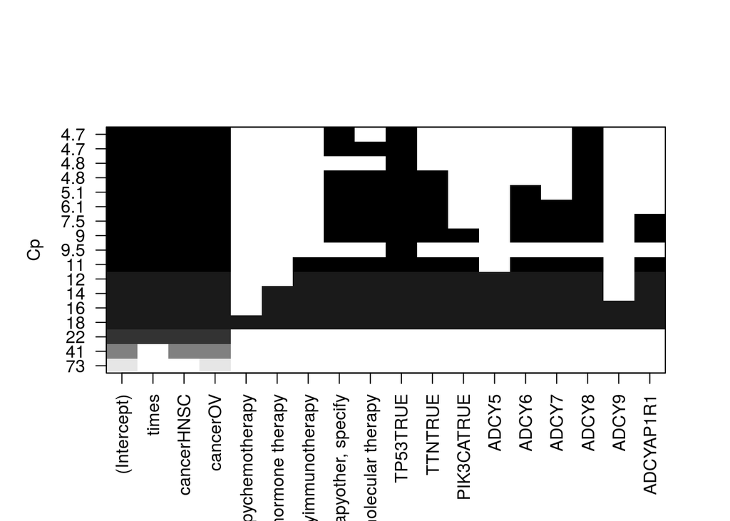

```r
library(leaps)

number_of_features <- nrow(glm_tidy) - 1
glm_model_fss <- regsubsets(x = status ~ ., data = train,
                            nvmax = number_of_features, method = "forward")
plot(glm_model_fss, scale = "Cp")
```

```r
glm_model_fss_summary <- summary(glm_model_fss)
glm_model_fss_summary
```

```
## Subset selection object
## Call: regsubsets.formula(x = status ~ ., data = train, nvmax = number_of_features,
##     method = "forward")
## 17 Variables  (and intercept)
##                                        Forced in Forced out
## times                                      FALSE      FALSE
## cancerHNSC                                 FALSE      FALSE
## cancerOV                                   FALSE      FALSE
## drug_therapychemotherapy                   FALSE      FALSE
## drug_therapyhormone therapy                FALSE      FALSE
## drug_therapyimmunotherapy                  FALSE      FALSE
## drug_therapyother, specify                 FALSE      FALSE
## drug_therapytargeted molecular therapy     FALSE      FALSE
## TP53TRUE                                   FALSE      FALSE
## TTNTRUE                                    FALSE      FALSE
```

[output cut: 99 more lines]

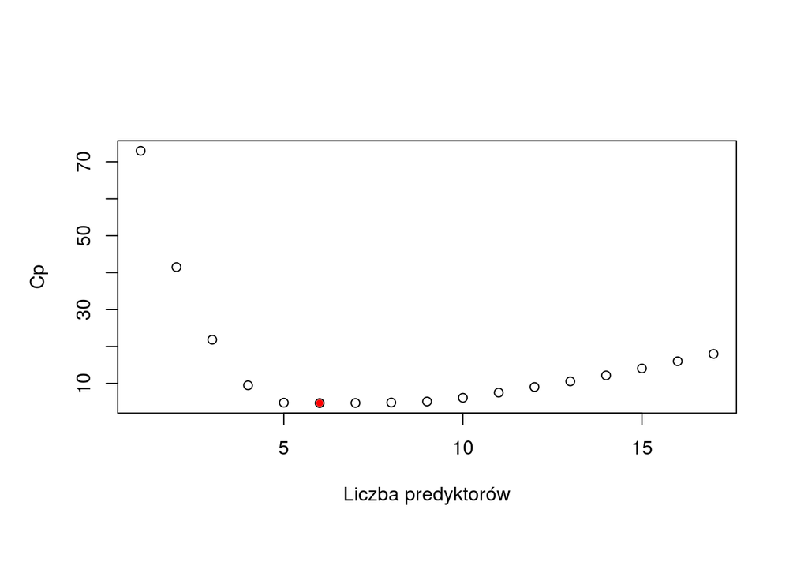

```r
plot(glm_model_fss_summary$cp, xlab = "Liczba predyktorów", ylab = "Cp")
points(which.min(glm_model_fss_summary$cp),
       min(glm_model_fss_summary$cp),
       pch = 20,
       col = "red")
```

Współczynnik Cp Mallowa uwzględnia rozmiar modelu. Można by wyjść z założenia, że im bardziej skomplikowany – polegający na większej ilości predyktorów model – tym lepszy. Nie jest to prawdą. Przy bardzo mocnym dopasowaniu modelu do danych może dojść do tzw. *overfittingu*. Model zbyt mocno dopasowany do danych może dawać gorsze predykcje niż ten spasowany w mniejszym stopniu. Okazuje się, że najodpowiedniejszy model w tym przypadku, to taki zbudowany na 6 zmiennych (o jedną więcej niż poprzedni model).

## k-krotna kroswalidacja

```r
# Na ile foldów (podzbiorów) podzielimy nasz zestaw treningowy
K <- 10

# Podział zestawu treningowego na podzbiory
set.seed(42)
folds <- sample(rep(1:K, length = nrow(train)))
table(folds)
```

```
## folds
##  1  2  3  4  5  6  7  8  9 10
## 98 98 98 98 98 98 98 98 98 98
```

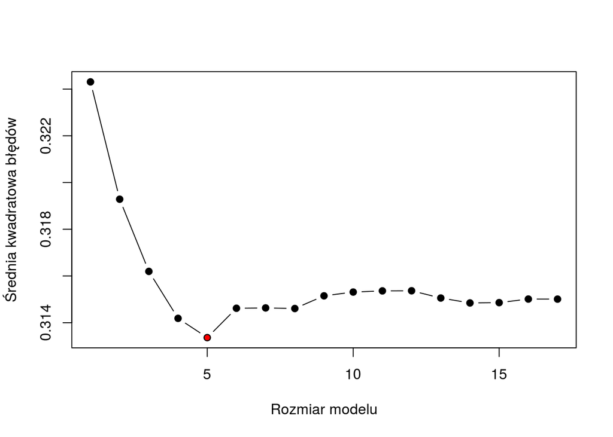

```r
# Macierz błędów
cv_errors <- matrix(NA, K, number_of_features)

# k-krotna kroswalidacja
predict.regsubsets <- function(object, formula, data, id) {
  mat <- model.matrix(formula, data)
  coefi <- coef(object, id = id)
  mat[, names(coefi)] %*% coefi
}

for (k in 1:K) {
  form <- as.formula(status ~ .)
  best_fit <- regsubsets(form,
                         train[folds != k, ],
                         nvmax = number_of_features,
                         method = "forward")
  for (i in 1:(glm_model_fss$nvmax - 1)) {
    pred <- predict.regsubsets(best_fit, form, train[folds == k, ], id = i)
    cv_errors[k, i] <- mean((train$status[folds == k] - pred) ^ 2)
  }
}

rmse_cv <- sqrt(apply(cv_errors, 2, mean))

plot(
  rmse_cv,
  xlab = "Rozmiar modelu",
  ylab = "Średnia kwadratowa błędów",
  pch = 19,
  type = "b"
)
points(which.min(rmse_cv),
       min(rmse_cv),
       pch = 20,
       col = "red")
```

# Inne algorytmy związane z doborem zmiennych

- Regresja Grzbietowa (Ridge Regression)
- Lasso

# Inne algorytmy związane z klasyfikacją

- Liniowa analiza dyskryminacyjna (LDA)

  Bardziej stabilna metoda klasyfikacji niż regresja logistyczna w wypadku, gdy istnieją zmienne objaśniające potrafiące niemalże idealnie odróżnić klasy (dla takich zmiennych współczynniki przy regresji logistycznej dążyłyby do nieskończoności). Regresja logistyczna została opracowana na płaszczyźnie biologii i medycyny, gdzie tak silne predyktory nie występują. LDA jest bardziej popularne w sytuacji, gdy mamy do czynienia z wiekszą ilością klas niż dwie.
- k najbliższych sąsiadów (k-NN)
- Lasy losowe (Random forest)
- Maszyna wektorów nośnych (SVM)
- Algorytm centroidów (k-means)

  Należy do grupy algorytmów uczenia bez nadzoru (przydziela obserwacje do klas nie mając wcześniej informacji, że takie istnieją).
- Sieci neuronowe

# Koniec

Na zakończenie – selekcja zmiennych za pomocą 3 metod na zbiorze danych zawierających eskpresje genów w postaci 20 tysięcy zmiennych.

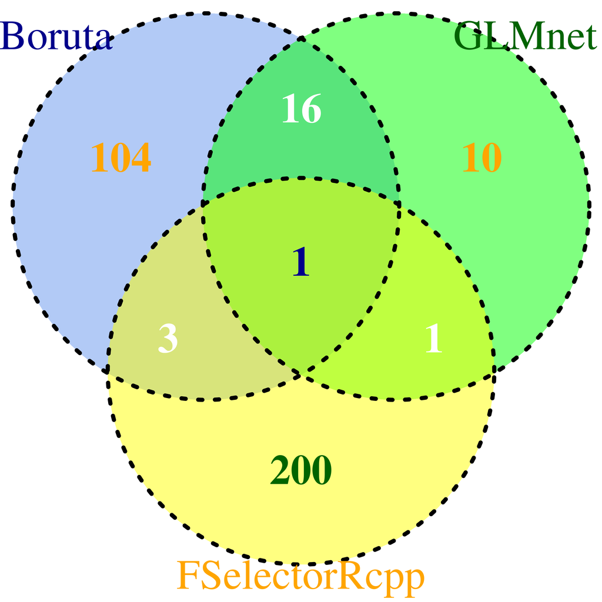